# Beginning MLOps with MLFlow (Getting Started: Data Analysis)

## Chapter One: Getting Stated: Data Analysis

In this notebook, we will go over the premise of the problem we are attempting to solve with the machine learning solution we want to operationalize. We will also begin data analysis and feature engineering of our data.

### Introduction and Premise

In this notebook we will be taking an example problem, developing a machine learning solution to it, and operationalizing our model on AWS SageMake, Microsoft Azurem Google Cloud, and Datarobots. The problem we will be looking at is the issue of performing anomaly detection on a credit card data set. In this notebook, we will explore this data set and show the overall structure while explaining a few techniques on analyzing this data.

The general process of how machine learning solutions are generally created goes like this:

**1. Identification of the problem.** First of all, you need to have an idea of what the problem is, what can be done about it, what has benn done about it, and why it is a problem worth solving.

Here's an example of a problem: an invasive snake species harmful to the local environment has infested a region. This species is highly venomous and looks very similar to a harmless species of snake native to this same enviornment. Furthermore, the invasive species is destructive to the local environment and is outcompeting the local species.

In response, the local government has issued a statement encouraging citizen to go out and kill the venomous, invasive species on sight, but the problem is that it turns out that citizen have been killing the local species as well due to how easy it is to cnfuse the two species.

What can be done about this? A possible solution is to use the power of machine learning and build an application to help citizens identify the snake species. What has been done about it? Perhaps someone released an app that does a poor job at distinguishing the two species, which doesn't help remedy the current solution. Perhaps fliers have been given out, but it can it can be hard to identify every member of a species correctly based on just one picture.

Why is it a problem worth solving? The native species is important to the local environment. Killing the wrong species can end up exacerbating the situation and lead to the invasive species ckaiming the environment over the native species. And so building a computer vision-based application that can discern between the various snake species (and specially the two species relevant to the problem) could be a great way to help citizens get rid of the rigth snake species.

**2. Collection of data.** After you've identified the problem, you want to collectr the relevant data. In the context of the snake species classification problem, you want to find images of various snake species in your region. The location depends on how big of a scale your project will operate on. Is it going to identify any snake in the world? Just snakes in Florida?

If you can afford to do so, the more data you collect, the better the potential training outcomes will be. More training examples can introduce increased variety to you model, making it better in the long run. Deep learning models scale in performance with large volumes of data, so keep that in mind as well.

**3. Data analysis.** Once you've collected all the raw data, you have to clean it up, process it, and format it in a way that allows you to analyze the data better.

For images, this could be something like applyign an algorithm to crop out unnecessary oarts of an image to focus solely on the snake. Additionally, maybe you want to center-crop the image to remove all the extra visual information in the data sample. Either way, raw image data is rarely ever good enough condition to be used directly; it almost always requires processing to get the relevant data you want.

For unstructured data like images, formatting this data in a way good enough to analyze it could be something like creating a directory with all of the respective snake species and the relevant image data. From there, you can look at the count of images for each snake species class that you have and determine if you need to retrieve more samples for a particular species of not.

For structured data, say the credit-card data set, processing the raw data can mean something like getting rid of any entries with null values in them. Formatting them in a way so you can analyze them better can involve dimensionality-reduction techniques as principal component analysis (PCA). Note: It turns out that most of the data in the credit card data set has actually been processed with PCA in part to preserve the privacy of the users the data has been extracted from.

As for the analysis, you can construct multiple graphs of different features to get an idean of the overall distribution and how the features look plotted against each other. This way, you can see any significant relationships between certain features that you might keep in mind when creating your training data.

There are some tools you can use in order to find out what features have the greatest influcen on the label, such as **phi-k correlation**. By allowing you to see the different correlation values between the individual features and the target label, you can gain deeper understanding of the relationships between the features in this data set. If needed, you can also drop features that aren't very influential from the data. In this step, you really want to get a solid understanding of you dats so you can apply a model architecture that is most suitable for it.

**4. Feature engineering and data processing.** Now you can use the knowledge you gained from analyzing the various features and their relationships to each another to potentially construct new features from combinations of several existing ones. For example, the Titanic data set is a great example that you can apply feature engineering to. In this case, you can take information such as class, age, fare, number of siblings, number of parents, and so on to create as many features as you can think up.

Feature engineering is really about giving your model a deeper context so it can learn the task better. You don't necessarily want to create random features for the sake of it, but something that's potentially relevant like number of female relatives, for example. (Since females were more likely to survive the sinking of the Titanic, could it be possible that if a person had more female relatives, they were less likely to survive as preference was given to their female relatives instead?)

The next step after the feature engineering is data processing, which is a step involving all preparations made to process the data to be passed into the model. In the context of the snake species image data, this could involve normalizing all the values to be between 0 and 1 as well as "batching" the data into groups.

This step also usually creates several subsets of you intiial data: a **training data set**, a **testing data set**, and a **validation data set**. We will go into more detail on the purpose of each of these data sets later. For now, a **training data set** contains the dta you want the model to learn from, the **testing data set** contains data you want to evaluate the model's performance on, and the **validation data set** is used to either select a model or help tune a model's **hyperparameters** to draw out a better performance.

**5. Build the model.** Now that the data processing is done, this step is all about selecting the proper architecture and building the model. For the snake species image data, a good choice would be to use a **convolutional neural network (CNN)** because they work very well for any tasks involving images. From there, it is up to you to define the specific architecture of the model with respect to its layer composition.

**6. Training, evaluating, and validating.** When you're training your CNN model, you're usually passing in batches of data until the entire data makes a full pass through the model. From the results of this **"forward pass"**, calculations are made that tell the model how to adjust the weights as they are made going backwards across the network in what's called the **"backward pass"**. The training process is essentially where the model learns how to perform the task and gets better at it the more examples it sees.

After the training process, either the evaluation step or the validation step can come next. As long as the testing set and the validation set come from different distributions (the validation set can be derived from the training set, while the testing set can be derived from the original data), the model is technically seeing new data in the evaluation and validation processses. The model will never learn anything from the evaluation data, so you can test your model anytime.

Model evaluation is where the model's performance metrics such as accuracy, precision, recall, and so on are evaluated on a data set that it has never seen before. We will go into more detail on the evaluation step once it becomes more relevant in the next notebook (Chapter Two).

Depending on the context, the exact purpose of validation can differ, along with the question of whether or not evaluation should be performed first after training. Let's define several sample scenarios where you should use validation:

**Selecting a model architecture.** Of several model types or achitectures, you use k-fold cross-validation, for example, to quickly train and evaluate each of the models on some data partition of the validation set to get an idea of how they are performing. This way, you can get a good idea of which model is performing best, allowing you to pick a model and continue with the rest of the processes.

**Selecting the best model.** Of several trained models, you can use something like k-fold cross-validation to quickly evaluate each model on the validation data to allow you get an idean of which one is performing best.

**Tuning hyperparameters.** Quickly train a model and test it with different hyperparameter setups to get an idean of which configurations work better. You can start with a broad range of hyperparameters. From there, you can use the results to narrow the range of hyperparameters until you get to a configuration where you are satisfied. Models in deep learning, for example, can have many hyperparameters, so using validation to tune those hyperparameters can work well in deep learning settings. Just beware of diminishing returns. After a certain precision with the hyperparameters setting, your're not going to see that big of a performance boost in the model.

**Indication of high variance.** This validation data is slightly different from the other three examples. In the case of neural networks, this data is derived from a small split of the training data. After one full pass on the training data, the model evaluates on this validation data to calculate metrics such as loss and accuracy.

If you training accuracy is high and training loss is low, but the validation accuracy is low and the validation loss is high, that's an indication that your model suffers from **high variance**. What this means is that your model has not learned to generalize what it is "learning" to new data, as the validation data in this case is comprised of data it has never seen before. In other words, your model is **overfitting**. The model just isn't recreating the kind of performance it gets on the training data on new data that it hasn't seen before.

If you model has poor training accuracy and high training loss, then your model suffers from **high bias**, meaning it isn't learning how to perform the task correctly on the training data at all.

This little validation split during the training process can give you an early indication of when **overfitting** is occurring.

**Predicting.** Once the model has been trained, evaluated, and validated, it is then ready to make predictions. In the context of the snak species detector, this step involves passing in visual images of the snake in question to get some prediction back. For example, if the model is supposed to detect the snake, draw a box around it, and label it (in an object detection mask), it will do so and display the results in real time in the application.

If it just classifies the snake in the picture, the user simply sends their photo of a snake to the model (via the application) to get a species classification prediction along with perhapsa probability confidence score.

Hopefully now you have a better idea of what goes on when creating machine learning solutions.

With all that in mind, let's get started on the example, where youwill use the credit card data set to build simple anomaly detection models using the data.

## Credit Card Data Set

Before you perform any data analysis, you need to first collect you data. Before exploring the data set, let's go over the exact packages and their versions:

To check your package versions, you can run outside of the IPython shell a command like

*pip show package_name*

Alternatively, you can run the following code to display the version in the notebook itself:

```python
import numpy as np
import pandas as pd
import matplotlib

print(np.__version__)
print(pd.__version__)
print(matplotlib.__version__)
```

```
1.19.5
0.24.2
2.2.2
```

## Loading the Data Set

let's begin! First, import all of the dependencies and set global parameters in this notebook.

```python
import numpy as np
import pandas as pd
import matplotlib.pyplot as plt
from pylab import rcParams

# Global parameter definition for the size of all matplotlib plots
rcParams['figure.figsize'] = 14, 8
```

Now that you have imported the necessary libraries, you can load the data set. In this case, the data folder exists in the same directory as the notebook file and contains the *creditcard.csv* file. Here is the code:

```python
df = pd.read_csv('creditcard.csv')
```

Now that the data frame has been loaded, let's take a look at its contents. Calling the *head()* fucntion on the data frame displays the first five rows of the data frame.

```python
df.head()
```

|  | Time | V1 | V2 | V3 | V4 | V5 | V6 | V7 | V8 | V9 | ... | V21 | V22 | V23 | V24 | V25 | V26 | V27 | V28 | Amount | Class |
| --- | --- | --- | --- | --- | --- | --- | --- | --- | --- | --- | --- | --- | --- | --- | --- | --- | --- | --- | --- | --- | --- |
| 0 | 0.0 | -1.359807 | -0.072781 | 2.536347 | 1.378155 | -0.338321 | 0.462388 | 0.239599 | 0.098698 | 0.363787 | ... | -0.018307 | 0.277838 | -0.110474 | 0.066928 | 0.128539 | -0.189115 | 0.133558 | -0.021053 | 149.62 | 0 |
| 1 | 0.0 | 1.191857 | 0.266151 | 0.166480 | 0.448154 | 0.060018 | -0.082361 | -0.078803 | 0.085102 | -0.255425 | ... | -0.225775 | -0.638672 | 0.101288 | -0.339846 | 0.167170 | 0.125895 | -0.008983 | 0.014724 | 2.69 | 0 |
| 2 | 1.0 | -1.358354 | -1.340163 | 1.773209 | 0.379780 | -0.503198 | 1.800499 | 0.791461 | 0.247676 | -1.514654 | ... | 0.247998 | 0.771679 | 0.909412 | -0.689281 | -0.327642 | -0.139097 | -0.055353 | -0.059752 | 378.66 | 0 |
| 3 | 1.0 | -0.966272 | -0.185226 | 1.792993 | -0.863291 | -0.010309 | 1.247203 | 0.237609 | 0.377436 | -1.387024 | ... | -0.108300 | 0.005274 | -0.190321 | -1.175575 | 0.647376 | -0.221929 | 0.062723 | 0.061458 | 123.50 | 0 |
| 4 | 2.0 | -1.158233 | 0.877737 | 1.548718 | 0.403034 | -0.407193 | 0.095921 | 0.592941 | -0.270533 | 0.817739 | ... | -0.009431 | 0.798278 | -0.137458 | 0.141267 | -0.206010 | 0.502292 | 0.219422 | 0.215153 | 69.99 | 0 |

5 rows × 31 columns

If you are not familiar with the *df.head(n)* function, it essentially prints the first n rows of the data frame. If you did not pass any arguments, like above, then the function defaults to a value of five, printing the first five rows of the data frame.

Feel free to play around with that function as well as use the scroll bar to explore the rest of the features.

Now, let's look at some basic statistical values relating to the values in this data frame. Calling the *describe()* function on the data frame to get statistical summaries of the data in each column.

```python
df.describe()
```

|  | Time | V1 | V2 | V3 | V4 | V5 | V6 | V7 | V8 | V9 | ... | V21 | V22 | V23 | V24 | V25 | V26 | V27 | V28 | Amount | Class |
| --- | --- | --- | --- | --- | --- | --- | --- | --- | --- | --- | --- | --- | --- | --- | --- | --- | --- | --- | --- | --- | --- |
| count | 284807.000000 | 2.848070e+05 | 2.848070e+05 | 2.848070e+05 | 2.848070e+05 | 2.848070e+05 | 2.848070e+05 | 2.848070e+05 | 2.848070e+05 | 2.848070e+05 | ... | 2.848070e+05 | 2.848070e+05 | 2.848070e+05 | 2.848070e+05 | 2.848070e+05 | 2.848070e+05 | 2.848070e+05 | 2.848070e+05 | 284807.000000 | 284807.000000 |
| mean | 94813.859575 | 1.165980e-15 | 3.416908e-16 | -1.373150e-15 | 2.086869e-15 | 9.604066e-16 | 1.490107e-15 | -5.556467e-16 | 1.177556e-16 | -2.406455e-15 | ... | 1.656562e-16 | -3.444850e-16 | 2.578648e-16 | 4.471968e-15 | 5.340915e-16 | 1.687098e-15 | -3.666453e-16 | -1.220404e-16 | 88.349619 | 0.001727 |
| std | 47488.145955 | 1.958696e+00 | 1.651309e+00 | 1.516255e+00 | 1.415869e+00 | 1.380247e+00 | 1.332271e+00 | 1.237094e+00 | 1.194353e+00 | 1.098632e+00 | ... | 7.345240e-01 | 7.257016e-01 | 6.244603e-01 | 6.056471e-01 | 5.212781e-01 | 4.822270e-01 | 4.036325e-01 | 3.300833e-01 | 250.120109 | 0.041527 |
| min | 0.000000 | -5.640751e+01 | -7.271573e+01 | -4.832559e+01 | -5.683171e+00 | -1.137433e+02 | -2.616051e+01 | -4.355724e+01 | -7.321672e+01 | -1.343407e+01 | ... | -3.483038e+01 | -1.093314e+01 | -4.480774e+01 | -2.836627e+00 | -1.029540e+01 | -2.604551e+00 | -2.256568e+01 | -1.543008e+01 | 0.000000 | 0.000000 |
| 25% | 54201.500000 | -9.203734e-01 | -5.985499e-01 | -8.903648e-01 | -8.486401e-01 | -6.915971e-01 | -7.682956e-01 | -5.540759e-01 | -2.086297e-01 | -6.430976e-01 | ... | -2.283949e-01 | -5.423504e-01 | -1.618463e-01 | -3.545861e-01 | -3.171451e-01 | -3.269839e-01 | -7.083953e-02 | -5.295979e-02 | 5.600000 | 0.000000 |
| 50% | 84692.000000 | 1.810880e-02 | 6.548556e-02 | 1.798463e-01 | -1.984653e-02 | -5.433583e-02 | -2.741871e-01 | 4.010308e-02 | 2.235804e-02 | -5.142873e-02 | ... | -2.945017e-02 | 6.781943e-03 | -1.119293e-02 | 4.097606e-02 | 1.659350e-02 | -5.213911e-02 | 1.342146e-03 | 1.124383e-02 | 22.000000 | 0.000000 |
| 75% | 139320.500000 | 1.315642e+00 | 8.037239e-01 | 1.027196e+00 | 7.433413e-01 | 6.119264e-01 | 3.985649e-01 | 5.704361e-01 | 3.273459e-01 | 5.971390e-01 | ... | 1.863772e-01 | 5.285536e-01 | 1.476421e-01 | 4.395266e-01 | 3.507156e-01 | 2.409522e-01 | 9.104512e-02 | 7.827995e-02 | 77.165000 | 0.000000 |
| max | 172792.000000 | 2.454930e+00 | 2.205773e+01 | 9.382558e+00 | 1.687534e+01 | 3.480167e+01 | 7.330163e+01 | 1.205895e+02 | 2.000721e+01 | 1.559499e+01 | ... | 2.720284e+01 | 1.050309e+01 | 2.252841e+01 | 4.584549e+00 | 7.519589e+00 | 3.517346e+00 | 3.161220e+01 | 3.384781e+01 | 25691.160000 | 1.000000 |

8 rows × 31 columns

Feel free to scroll right and look at the various statistics for the rest of the columns. As you can see, the function generates statistical summaries for data in each of the columns of the data frame.

The main takeaway here is that there are a huge number of data points. In fact, you can check the shape of the data frame by simply calling *shape*. Calling the *shape()* function on the data frame to get an ouput in the format *(number_of_rows, number_of_columns)*.

```python
df.shape
```

```
(284807, 31)
```

There are 284,807 rows and 31 columns in this data frame. That's a lot of entries! Not only that, but if you look at the above statistical description of the data, you'll see that the values can get really large for the column *Time*. In fact, keep scrolling right, and you'll see that values can get very large for the column *Amount* as well. Scrolling right in the output of the *describe()* reveals that the maximum data value in the column *Amount* is also very large, just like the maximum data value in the column *Time*.

As you can see, there are at least two columns with very large values. What this tells you is that later on, when building the various data sets for the model training process, you definitely need to scale down the data. Otherwise, such large data values can potentially mess up the training process.

## Normal Data and Fraudulent Data

Since the are only two classes, *normal* and *fraud*, let's split up the data frame by class and continue with the data analysis. In the context of the anomaly detection, the *fraud* class is also the *anomaly* class, hence why we chose to name the data frame representing fraudulent transaction data anomalies and interchangeably refer to this class as either *fraud* or *anomaly*. Here is the code.

```python
anomalies = df[df.Class == 1]
normal = df[df.Class == 0]
```

After that, run the following in a separate cell.

```python
print(f"Anomalies: {anomalies.shape}")
print(f"Normal:{normal.shape}")
```

```
Anomalies: (492, 31)
Normal:(284315, 31)
```

From here, you can see that the data is overwhelming biased towards normal data, and that anomalies only comprise a vast minority of the data points in the overall data set. What this tells you is that you will have to craft the training, evaluation, and validation sets more carefully so each of these set will have a good representation of anomaly data.

In fact, let's look at this disparity in a graphical manner just to see how large the difference is.

```
Text(0,0.5,'Counts')
```

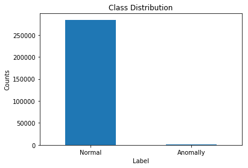

```python
class_counts = pd.value_counts(df['Class'], sort = True)
class_counts.plot(kind = 'bar', rot = 0)
plt.title('Class Distribution')
plt.xticks(range(2), ['Normal', 'Anomally'])
plt.xlabel('Label')
plt.ylabel('Counts')
```

The graph visually shows the immense difference between the number of data values of the two classes.

So now you can begin analyzing some of the characteristics of data points in each class. First of all, the columns in this data set are *Time*, values *V1* through *V28*, *Amount*, and *Class*.

So, do anomalous data values comprise transactions with excessive amounts? Let's look at some statistical summary values fro "Amount":

```python
anomalies.Amount.describe()
```

```
count     492.000000
mean      122.211321
std       256.683288
min         0.000000
25%         1.000000
50%         9.250000
75%       105.890000
max      2125.870000
Name: Amount, dtype: float64
```

The above is the output of the *describe()* function on the data frame for fraudulent values for the column *Amount*.

It seems like that data is skewed right, and that anomalous transactions comprise values that are not very high. In fact, most of the transactions are less that \$100, so it's not like fraudulent transaction are high-value transactions.

```python
normal.Amount.describe()
```

```
count    284315.000000
mean         88.291022
std         250.105092
min           0.000000
25%           5.650000
50%          22.000000
75%          77.050000
max       25691.160000
Name: Amount, dtype: float64
```

If you look at the normal data, it's even more skewed right than the anomalies. Most of the transactions are below \$100, and some of the amounts can be very high to values like \\$25,000.

## Plotting

Let's now turn to a graphical apporach to help visually illustrate this better. First, you define some function to help plot the various columns of the data to make it much easier to visualize the various relationships. Each of the plotter functions in their own Jupyter cell:

```python
def plot_histogram(df, bins, column, log_scale = False):

    bins = 100

    anomalies = df[df.Class == 1]
    normal = df[df.Class == 0]

    fig, (ax1, ax2) = plt.subplots(2, 1, sharex = True)
    fig.suptitle(f'Counts of {column} by Class')

    ax1.hist(anomalies[column], bins = bins, color = 'red')
    ax1.set_title('Anomaly')

    ax2.hist(normal[column], bins = bins, color = 'orange')
    ax2.set_title('Normal')

    plt.xlabel(f'{column}')
    plt.ylabel('Count')

    if log_scale:
        plt.yscale('log')
    plt.xlim((np.min(df[column]), np.max(df[column])))
    plt.show()
```

```python
def plot_scatter(df, x_col, y_col, sharey = False):

    anomalies = df[df.Class == 1]
    normal = df[df.Class == 0]

    fig, (ax1, ax2) = plt.subplots(2, 1, sharex = True, sharey = sharey)
    fig.suptitle(f'{y_col} over {x_col} by Class')

    ax1.scatter(anomalies[x_col], anomalies[y_col], color = 'red')
    ax1.set_title('Anomaly')

    ax2.scatter(normal[x_col], normal[y_col], color = 'orange')
    ax2.set_title('Normal')

    plt.xlabel(x_col)
    plt.ylabel(y_col)
    plt.show()
```

Now, let's start by plotting values for *amount* by Class for the entire data frame.

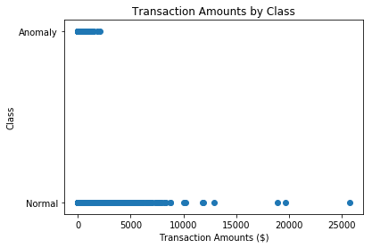

```python
plt.scatter(df.Amount, df.Class)
plt.title('Transaction Amounts by Class')
plt.ylabel('Class')
plt.yticks(range(2), ['Normal', 'Anomaly'])
plt.xlabel('Transaction Amounts (\\$)')
plt.show()
```

A scatterplot of data values in the data frame encompassing all the data values. The plotted columns are *Amount* on the x-axis and Class on the y-axis.

It seems like there are some massive outliers in the normal data set, as suspected. However, the graph isn't very informative in telling you about value counts, so let's use the plotting functions defined earlier to draw graphs that provide more context:

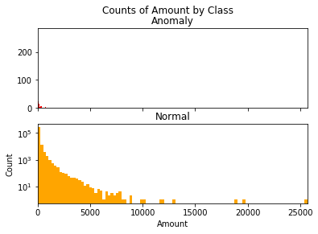

```python
bins = 100

plot_histogram(df, bins, 'Amount', log_scale = True)
```

A histogram of counts for data values organized into intervals in the column *Amount* in the data frame. The number of bins is 100, meaning the interval of each bar in the histogram is the range of the data in the column *Amount* divided by the number of bins.

From this, you can definitely notice a right skew as well as the massive outliers present in the normal data. Since you can't really see much ofthe anomalies, let's create another plot:

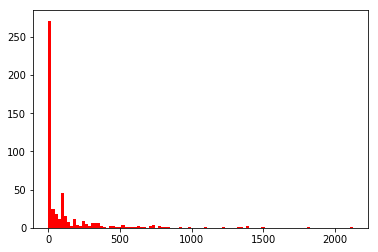

```python
plt.hist(anomalies.Amount, bins = bins, color = 'red')
plt.show()
```

A histogram of just the values in the anomaly data frame for the column *Amount*. The number of bins is also 100 here, as it will be for the rest of the examples.

The anomalies seem seem to be right skewed as well, but much more heavily so. This means that the majority of the anomalous transactions actually have quite low transaction amounts.

Alright, so what about time? Let's plot another basic scatterplot:

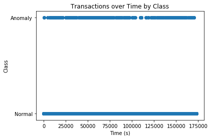

```python
plt.scatter(df.Time, df.Class)
plt.title('Transactions over Time by Class')
plt.ylabel('Class')
plt.yticks(range(2), ['Normal', 'Anomaly'])
plt.xlabel('Time (s)')
plt.show()
```

A scatterplot for values in the data frame df with data in the column *Time* on the x-axis and data in the column *Class* in the y-axis.

This graph isn't very informative, but it does tell you that fraudulent transactions are pretty spread out over the entire timeline. Once again, let's use the plotter functions to get idea of the counts:

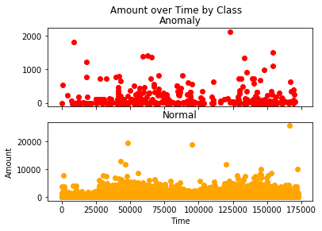

```python
plot_scatter(df, 'Time', 'Amount')
```

We Used the *plot_scatter()* function to plot data values for the columns *Time* on the x-axis and *Amount* on the y-axis in the df data frame.

You have a better context now, but it doesn't seem to tell you much. You can see that fraudulent transactions occur throughout the entire timeline and that there is no specific period of time when it seems like higher-value transaction occur. There do seem to be two main clusters but this could also be a result of the lack of data points compared to the normal points.

Let's now look at the histogram to take into account frequencies.

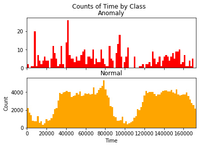

```python
plot_histogram(df, bins, 'Time')
```

We used the *plot_historgram()* function to plot data values for the column *Time* in the dataframe.

From this, you get a really good context of the amount of fraudulent anomalous transactions going over time. For the normal data, it seems that they occur in waves. For the anomalies, there doesn't seem to be a particular peak time; they just occur throughout the entire timespan.

It does appear that they have defined spikes near the start of the first transaction, and that some of the spikes do occur where normal transactions are in the "trough" of the wave pattern shown. However, a good protion of the fraudulent transactions still occur where normal transactions are at a maximum.

So what does the data for the other columns look like? Let's look at some interesting plots for V1:

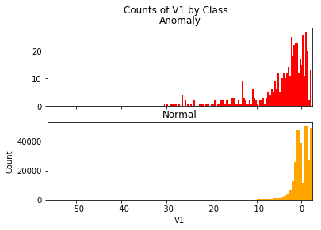

```python
plot_histogram(df, bins, 'V1')
```

We used the *plot_histogram()* function to plot the data in the column V1 in df.

Here, you can see a clear difference in the distribution of points for each class over the same *V1* values. The range of values that the fraudulent transactions encompass extend well in the values for *V1*. Let's keep exploring, looking at how the values for the *Amount* relate to *V1*:

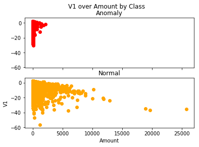

```python
plot_scatter(df, 'Amount', 'V1', sharey = True)
```

We used the *plot_scatter()* function to plot the values in the columns *Amount* on the x-axis and *V1* on the y-axis in df.

What the *sharey* parameter does is it forces both subplots to share the same y-axis, meaning the plots are displayed on the same scale. You are specifying this so it will be easier to tell waht the distribution of the anomalous points looks like in comparison to the normal points.

From this graph, the fraudulent points don't seem out of place compared to all of the other normal points.

Let's continue and look at how time relates to the values for *V1*:

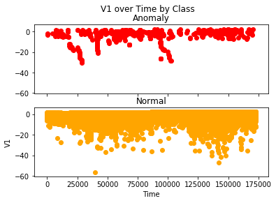

```python
plot_scatter(df, 'Time', 'V1', sharey = True)
```

We used the *plot_scatter()* function to plot the values in the columns *Time* on the x-axis and *V1* on the y-axis.

Other than a few defined spikes that stand out from where the normal points would have been, most of the fraudulent data in this context seems to blend in with the normal data.

Doing this one at a time for all the other values will be tedious, so let's just plot them all at once using a simple script. Here is the code to plot all of the frequency counts for each column from *v1* to *V28*.

```
V1 Counts
```

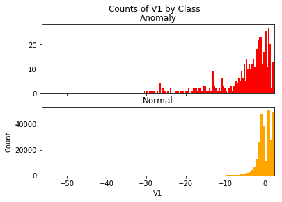

```
V2 Counts
```

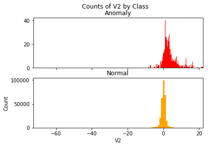

```
V3 Counts
```

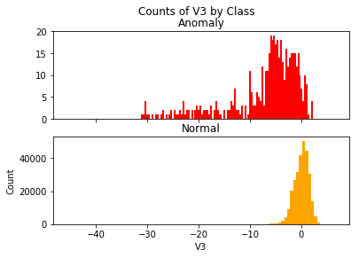

```
V4 Counts
```

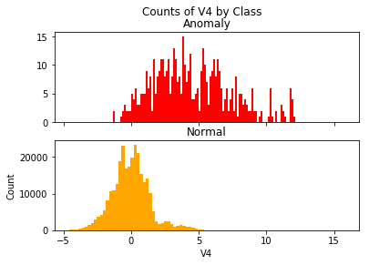

```
V5 Counts
```

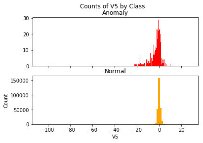

```
V6 Counts
```

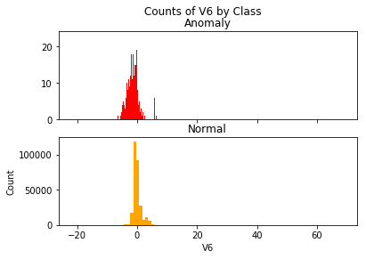

```
V7 Counts
```

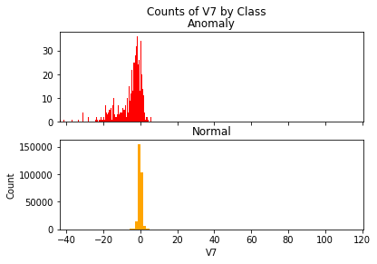

```
V8 Counts
```

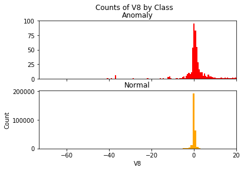

```
V9 Counts
```

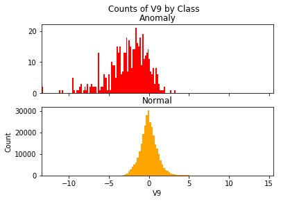

```
V10 Counts
```

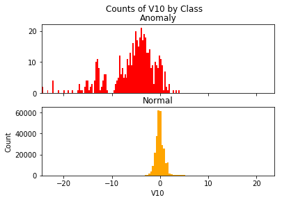

```
V11 Counts
```

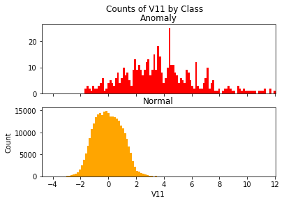

```
V12 Counts
```

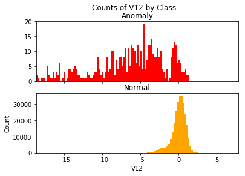

```
V13 Counts
```

[16 more figures not shown]

```python
for f in range(1, 29):
    print(f'V{f} Counts')
    plot_histogram(df, bins, f'V{f}')
```

A script to plot histograms using the *plot_histogram()* function for data in each column from *V1* to *V28* in df.

Scrolling through, you can see a lot of interesting graphs such as the graph corresponding to *V12*.

On the histogram corresponding to data for *V12* you can see that there is a very clear deviation seen with the anomalous values compared to the normal values. Both plots share the same x-axis scale, so while the counts might be very low compared to the normal values, they are still spread out far more than the normal values for the same range of *V12* column values.

In this case, you can see a clear differentiation between the fraudulent data and the normal data that you didn't see in the graphs earlier. And so, features suhc as *V12* are certainly more important in helping give the model a better context.

On the histogram corresponding to data for *V17* in df, just like with the column *V12*, there is also a clear deviation seen with the anomalous values compared to the normal values. This indicates that the column *V17* is more likely to help the model learn how to differentiate between a normal and fraudulent transaction than some of the other columns that don't show such a deviance.

This time you can see an even bigger difference between the fraudulent data and normal data. Once againm it's features like *V12* and *V17* that hold the data that will help the model understand how to differentiate between the anomalies and the normal points.

To minimize the ourpur, click the same bar as earlier when you exapanded the output. Let's now look at all of these data points vary according to time:

```
V1 vs Time
```

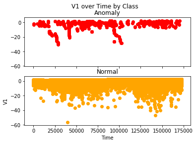

```
V2 vs Time
```

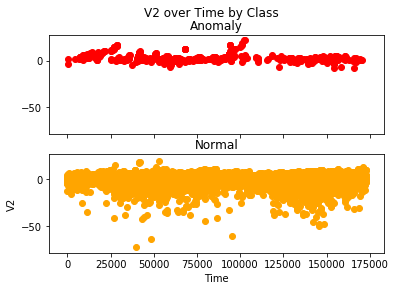

```
V3 vs Time
```

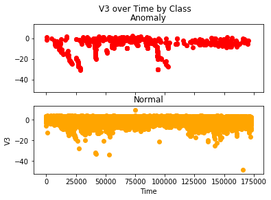

```
V4 vs Time
```

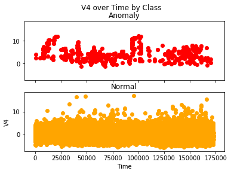

```
V5 vs Time
```

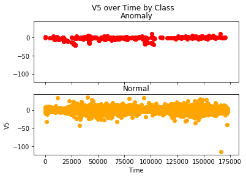

```
V6 vs Time
```

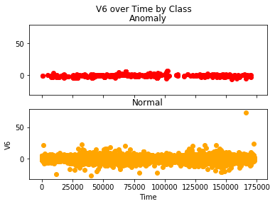

```
V7 vs Time
```

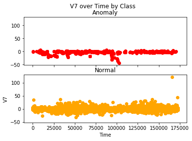

```
V8 vs Time
```

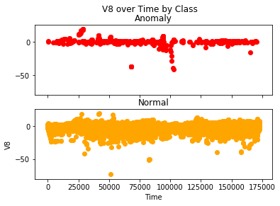

```
V9 vs Time
```

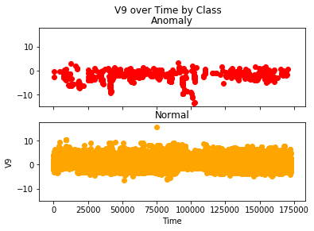

```
V10 vs Time
```

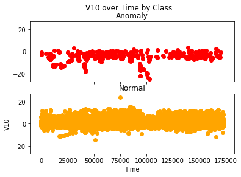

```
V11 vs Time
```

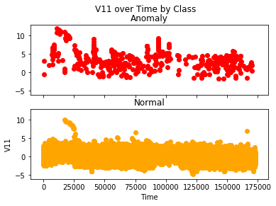

```
V12 vs Time
```

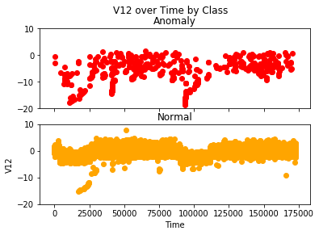

```
V13 vs Time
```

[16 more figures not shown]

```python
for f in range(1, 29):
    print(f'V{f} vs Time')
    plot_scatter(df, 'Time', f'V{f}', sharey = True)
```

Once again, expand the output and explore the graphs.

The scatterplot for *Time* on the x-axis and *V12* on the y-axis shows a deviation between the anomalies and the normal data points. Although a significant portion of the anomalies fall under the band of normal points, there are still a good number of anomalies that fall out of that range. And so you can see that against *Time*, the data for column *V12* also shows this deviation from the normal data points.

Once againm, with *V12* youn can see a significant difference between the anomalies and the normal data points. A good portion of the anomalies remain hidden within the normal data points, but a significant amount of them can be differentiated from the rest.

The scatterplot for the *Time* on the x-axis and *V17* on the y-axis shows a deviation between the anomalies and the normal data points. As with the values for *V12*, you can observe another deviation between the normal points and the fraudulent points. In this case, the difference seems to be a bit more pronounced, as the anomalies seem to be more spread out than for the *V12* case.

The difference between the anomalies and the normal points are highlighted even further when looking at *V17*. It seems that even in relation to *Time*, columns *V12* and *V17* hold data that best help distinguish fraudulent transactions from normal transactions. You can see in the graph that a few normal points are with the anomalous points as well, but hopefully the model can learn the true difference taking into account all of the data.

Finally, let's see the relationship between each of these columns and *Amount*:

```
Amount vs V1
```

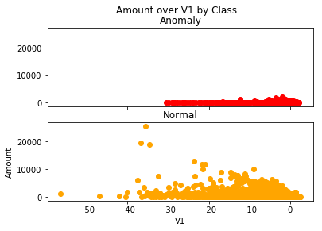

```
Amount vs V2
```

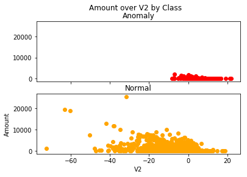

```
Amount vs V3
```

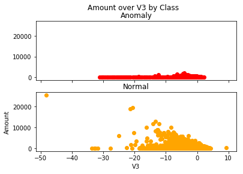

```
Amount vs V4
```

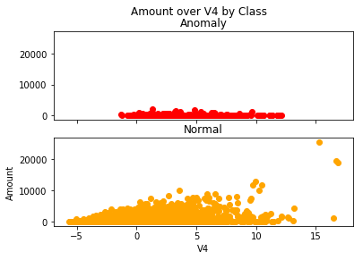

```
Amount vs V5
```

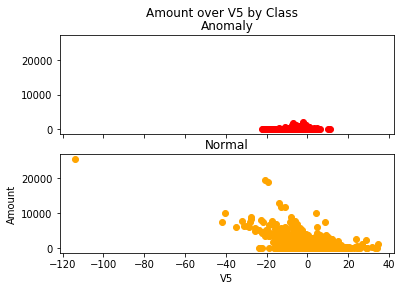

```
Amount vs V6
```

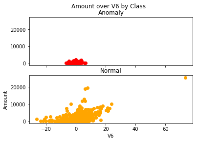

```
Amount vs V7
```

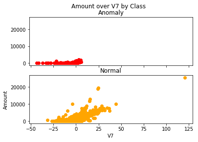

```
Amount vs V8
```

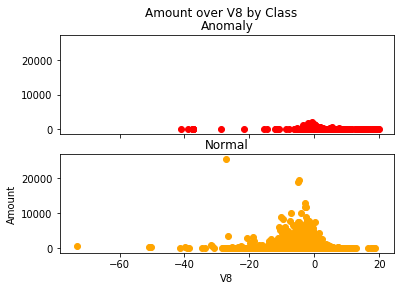

```
Amount vs V9
```

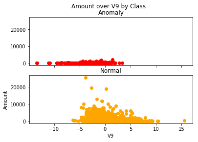

```
Amount vs V10
```

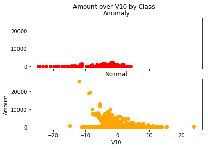

```
Amount vs V11
```

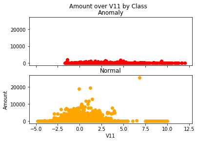

```
Amount vs V12
```

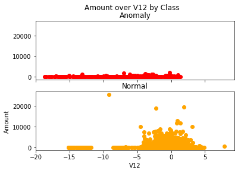

```
Amount vs V13
```

[16 more figures not shown]

```python
for f in range(1, 29):
    print(f'Amount vs V{f}')
    plot_scatter(df, f'V{f}', 'Amount', sharey = True)
```

This time there seems to be a few more graphs more clearly showing the difference between the normal and the fraudulent points.

looking at the scatterplot for *Amount* on the y-axis and *V10* on the x-axis, you can see a pronounced deviation of fraudulent points from the normal points. For the relationship of the *V* columns against *Amount*, it seems that more columns show an increased deviation compared to the earlier plots. This difference is not so large, as you still see that a sizeable portion of the anomalies are within the normal data cluster. However, this still gives the model some context in how a fraudulent transaction differs from a normal transaction.

The graphs from *V9* through *V12* all show a clear difference between the anomalies and the normal points, even if a good portion of the anomalies are within the cluster of normal points. One thing to note is that it may not be ther same anomalies that differ each time in the graphs, allowing the model to better learn how to differentiate between the anomalies and the normal points.

The scatterplot for the column *Amount* on the y-axis and *V12* on the x-axis. Once again, you can see a pronounced deviation of the fraudulent points from the normal points, In this case, the majority of the fraudulent points seem to deviate from the normal point cluster. You can also see that there is a band of normal points far from the main cluster, and that the band coincides with the anomalous data points. It is a possible reason to keep in mind if the model classifies points like these as anomalies.

You can once again see that *V12* consistently differentiates between anomalies and normal data. However, there is still the problem of a good portion of the anomalies staying hidden within the normal data cluster.

The scatterplot for the column *Amount* on the y-axis and *V17* on the x-axis shows a deviation again of fraudulent points from the normal point cluster. Once again the majority of the fraudulent points show this deviation, but you can also see some normal points that coincide with these anomalous points.

You can also see that this differentiation between normal points and fraudulent points holds for *V17* looking at transaction amounts.

You could also look at the data for each of the *V* columns and plot them against each other, but that's more useful to help identifying precise changes in trends that will be more useful to know if you want to further train the model to improve its performance on the new data. First of all, it's possible that not every feature is very significant. So, if trends do shift, it does not necessarily mean that the model's performance will be downgrading.

## Summary

Data analysis is a crucial step in the process of creating a machine learning solution. Not only does it determine the type of model and influence the set of festures that will be selected for the training process, but ti also helps identifying any changes in trends over time that may signify that the model needs to be further trained. You explored and analyzed the data in the credit card data set, generated many plots to get an idean of the relationship between the two plotted variables, and identified some of the features that distinguish between normal points and anomalies. In the next notebook, you will process the data to create various subsets to help train several types of machine learning models.

Reference: Alla, S., & Adari, S. K. Beginning MLOps with MLFlow.